# Data Science Job Positions on Indeed. Observations and Analysis

**Hello and welcome to the Data Science Job Positions on Indeed project.**</br> First, this is a revisited project that will give you an idea of the jobs on indeed in over 21 cities in the United States that were published and scraped in August 2017.

The dataset has over 619 advertized positions that mention annual/monthly/daily/hourly salaries. Further code and findings will be based on such observations. Our task was to predict if in a given city, we will be able to predict that the salary in the city would be above or below the overall median. The median was selected as a parameter for our set due to a strong skew to the right, for that reason the mean would not be desciptive of the data set.

I decided to add statistical data for each city and see if the statistical data can help predict if the mean salary would be below or above the overall median salary.

If you are mostly interested in the structure of the web-scaping code, please proceed to the very bottom of the page.

```python
import numpy as np
import pandas as pd
from bs4 import BeautifulSoup
import requests
import re
import time
import sklearn
from sklearn.ensemble import RandomForestClassifier
from sklearn import datasets
from sklearn.model_selection import train_test_split
from sklearn.feature_selection import SelectFromModel
from sklearn.metrics import accuracy_score
```

## Part 1. Data set and EDA

```python
df = pd.read_csv('../data/jobsdf.csv')
```

```python
print df.shape
df.head()
```

```
(15187, 8)
```

|  | Unnamed: 0 | jobtitle | company | city | location | salarytxt | paybase | summary |
| --- | --- | --- | --- | --- | --- | --- | --- | --- |
| 0 | 0 | machine learning engineer (associate) - intell... | JP Morgan Chase | New+York%2CNY | New York, NY 10001 (Chelsea area) | NaN | NaN | jp morgan intelligent solutions (jpmis) is a n... |
| 1 | 1 | data science developer | Morgan Stanley | New+York%2CNY | New York, NY 10032 (Washington Heights area) | NaN | NaN | as a data scientist developer your role will b... |
| 2 | 2 | quantitative analysis, full time analyst (nort... | Citi | New+York%2CNY | New York, NY | NaN | NaN | you're the brains behind our work. you’re read... |
| 3 | 3 | sr data scientist | Fimo Info Solutions LLC | New+York%2CNY | New York, NY | 110000.0 | annual | sr data scientist, nyc*. the data scientist wi... |
| 4 | 4 | tech lead - data scientist, nlp | Grubhub | New+York%2CNY | New York, NY | NaN | NaN | good understanding of data structures and comp... |

Next steps:

```
- Drop column "Unnamed: 0"
- Drop all records that don't mention salaries leaves only 857 records
- See what's left
```

```python
# Dropping "Unnamed: 0" and all lines that don't contain salaries
df = df[df.paybase.isnull() == False]
df.drop("Unnamed: 0", axis = 1, inplace = True)
print df.shape
df.head()
```

```
(857, 7)
```

|  | jobtitle | company | city | location | salarytxt | paybase | summary |
| --- | --- | --- | --- | --- | --- | --- | --- |
| 3 | sr data scientist | Fimo Info Solutions LLC | New+York%2CNY | New York, NY | 110000.0 | annual | sr data scientist, nyc*. the data scientist wi... |
| 6 | climate and sustainability analyst | DEPT OF ENVIRONMENT PROTECTION | New+York%2CNY | New York, NY | 65977.0 | annual | knowledge and practical application of quantit... |
| 7 | data analyst | POLICE DEPARTMENT | New+York%2CNY | New York, NY | 79249.5 | annual | extensive knowledge of applied statistics, ana... |
| 15 | data specialist, bureau of systems strengtheni... | DEPT OF HEALTH/MENTAL HYGIENE | New+York%2CNY | Queens, NY | 65600.0 | hourly | experience and the ability to conduct evaluati... |
| 20 | assistant research scientist i grade 14 job #1... | New York State Psychiatry Institute | New+York%2CNY | New York, NY | 32000.0 | hourly | the assistant research scientist is responsibl... |

Drop duplicates

```python
df.drop_duplicates(inplace = True)
df.reset_index(inplace = True)
df.drop("index", axis = 1, inplace = True)
print df.shape
df.head()
```

```
(619, 7)
```

|  | jobtitle | company | city | location | salarytxt | paybase | summary |
| --- | --- | --- | --- | --- | --- | --- | --- |
| 0 | sr data scientist | Fimo Info Solutions LLC | New+York%2CNY | New York, NY | 110000.0 | annual | sr data scientist, nyc*. the data scientist wi... |
| 1 | climate and sustainability analyst | DEPT OF ENVIRONMENT PROTECTION | New+York%2CNY | New York, NY | 65977.0 | annual | knowledge and practical application of quantit... |
| 2 | data analyst | POLICE DEPARTMENT | New+York%2CNY | New York, NY | 79249.5 | annual | extensive knowledge of applied statistics, ana... |
| 3 | data specialist, bureau of systems strengtheni... | DEPT OF HEALTH/MENTAL HYGIENE | New+York%2CNY | Queens, NY | 65600.0 | hourly | experience and the ability to conduct evaluati... |
| 4 | assistant research scientist i grade 14 job #1... | New York State Psychiatry Institute | New+York%2CNY | New York, NY | 32000.0 | hourly | the assistant research scientist is responsibl... |

```python
def eda(dataframe):
    print "missing values \n", dataframe.isnull().sum()
    print "dataframe index \n", dataframe.index
    print "dataframe types \n", dataframe.dtypes
    print "dataframe shape \n", dataframe.shape
    print "dataframe describe \n", dataframe.describe()
    for item in dataframe:
        print item
        print dataframe[item].nunique()

eda(df)
```

```
missing values
jobtitle     0
company      0
city         0
location     0
salarytxt    0
paybase      0
summary      0
dtype: int64
dataframe index
RangeIndex(start=0, stop=619, step=1)
dataframe types
jobtitle      object
company       object
city          object
location      object
salarytxt    float64
paybase       object
summary       object
dtype: object
dataframe shape
(619, 7)
dataframe describe
           salarytxt
count     619.000000
mean    95153.390953
std     46808.678054
min     19200.000000
25%     60262.750000
50%     86400.000000
75%    125000.000000
max    300000.000000
jobtitle
489
company
288
city
29
location
185
salarytxt
266
paybase
3
summary
575
```

```python
df.describe()
```

|  | salarytxt |
| --- | --- |
| count | 619.000000 |
| mean | 95153.390953 |
| std | 46808.678054 |
| min | 19200.000000 |
| 25% | 60262.750000 |
| 50% | 86400.000000 |
| 75% | 125000.000000 |
| max | 300000.000000 |

### Plotting part

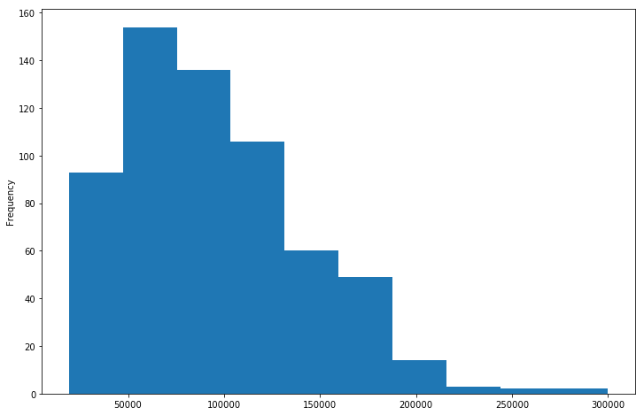

```python
import matplotlib.pyplot as plt
df.salarytxt.plot.hist(figsize = (12,8),bins=10)
plt.show()
```

### And here I am checking if there are any lines left with salaries below $20K

```python
df[df.salarytxt < 20000]
```

|  | jobtitle | company | city | location | salarytxt | paybase | summary |
| --- | --- | --- | --- | --- | --- | --- | --- |
| 267 | market research analyst/quality assurance | RDAssociates, Inc. | Philadelphia | Narberth, PA | 19200.0 | hourly | marketing research and consulting firm seeks a... |
| 365 | data analysis intern | hear.com | Miami | Miami, FL 33138 (Upper Eastside area) | 19200.0 | hourly | hear.com, the leading innovator in providing m... |

### Groupping by cities to see what is the situation with salaries positions are there for each city

```
city
Atlanta                  25
Austin                   22
Baltimore                25
Boston                   42
Charlotte                12
Chicago                  29
Columbus                  6
Dallas                    9
Denver                    9
Detroit                   4
Fort Worth                3
Houston                  24
Kansas+City               7
Los+Angeles              25
Mesa%2CAZ                11
Miami                    15
Minneapolis               5
New+York%2CNY           111
Philadelphia             25
Phoenix                   9
Pittsburgh                7
Portland%2COR            12
Raleigh                  21
San+Antonio%2CTX          2
San+Diego                13
San+Francisco            35
San+Jose                 29
Seattle                  23
Washington+City%2CDC     59
Name: summary, dtype: int64
```

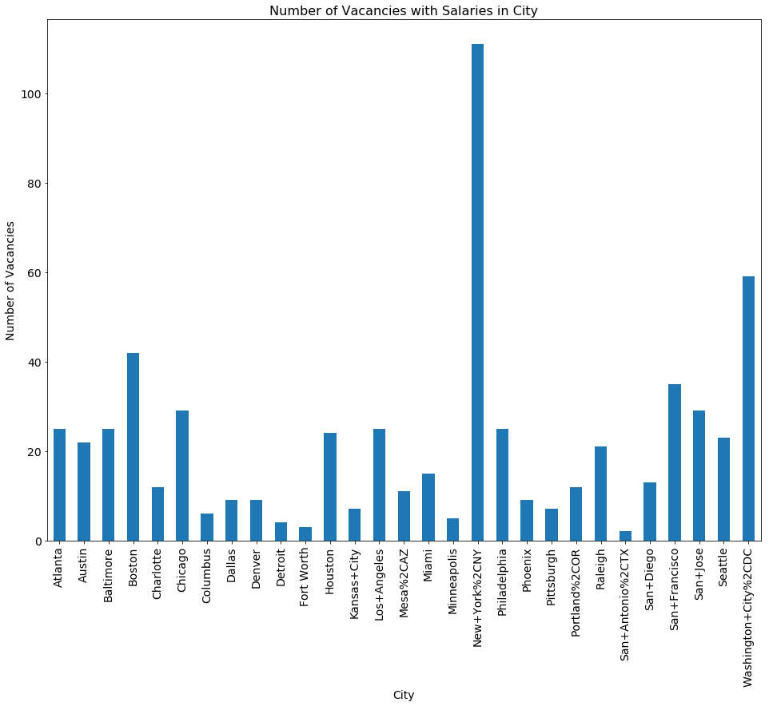

```python
print df.groupby(df.city)['summary'].count()
df.groupby(df.city)['summary'].count().plot(figsize = (16,12),kind = 'bar', fontsize = 14)
_ = plt.title("Number of Vacancies with Salaries in City", fontsize = 16)
_ = plt.ylabel("Number of Vacancies", fontsize = 14)
_ = plt.xlabel("City", fontsize = 14)
plt.show()
```

### Now let's save the median on salary

```python
median = df.salarytxt.median()
median
```

```
86400.0
```

### I also found some statistics for major cities. This includes: population, density, dpf, latitude, longitude, and median houshold income

```python
cities = pd.read_csv('../data/city_stats.csv')
cities.dropna(inplace = True)
```

```python
cities.head()
```

|  | City | State | Population | Density | DPF | Latitude | Longitude | MedianHHInc | Ppower |
| --- | --- | --- | --- | --- | --- | --- | --- | --- | --- |
| 0 | New+York%2CNY | New York | 8537673 | 27012 | 230619.62 | 40.6643 | 73.9385 | 59799.0 | 100.0 |
| 1 | Los+Angeles | California | 3976322 | 8092 | 32176.40 | 34.0194 | 118.4108 | 45903.0 | 118.0 |
| 2 | Chicago | Illinois | 2704958 | 11842 | 32032.11 | 41.8376 | 87.6818 | 51046.0 | 118.0 |
| 3 | Philadelphia | Pennsylvania | 1567872 | 11379 | 17840.82 | 40.0094 | 75.1333 | 47528.0 | 116.0 |
| 4 | San+Francisco | California | 870887 | 17179 | 14960.97 | 37.7751 | 122.4193 | 63024.0 | 102.0 |

### Then I merge the original dataframe with statistics for each city and will drop one "City" column

```python
jobs = pd.merge(df, cities, left_on = 'city', right_on = 'City', how = "inner")
jobs
```

|  | jobtitle | company | city | location | salarytxt | paybase | summary | City | State | Population | Density | DPF | Latitude | Longitude | MedianHHInc | Ppower |
| --- | --- | --- | --- | --- | --- | --- | --- | --- | --- | --- | --- | --- | --- | --- | --- | --- |
| 0 | sr data scientist | Fimo Info Solutions LLC | New+York%2CNY | New York, NY | 110000.0 | annual | sr data scientist, nyc*. the data scientist wi... | New+York%2CNY | New York | 8537673 | 27012 | 230619.62 | 40.6643 | 73.9385 | 59799.0 | 100.0 |
| 1 | climate and sustainability analyst | DEPT OF ENVIRONMENT PROTECTION | New+York%2CNY | New York, NY | 65977.0 | annual | knowledge and practical application of quantit... | New+York%2CNY | New York | 8537673 | 27012 | 230619.62 | 40.6643 | 73.9385 | 59799.0 | 100.0 |
| 2 | data analyst | POLICE DEPARTMENT | New+York%2CNY | New York, NY | 79249.5 | annual | extensive knowledge of applied statistics, ana... | New+York%2CNY | New York | 8537673 | 27012 | 230619.62 | 40.6643 | 73.9385 | 59799.0 | 100.0 |
| 3 | data specialist, bureau of systems strengtheni... | DEPT OF HEALTH/MENTAL HYGIENE | New+York%2CNY | Queens, NY | 65600.0 | hourly | experience and the ability to conduct evaluati... | New+York%2CNY | New York | 8537673 | 27012 | 230619.62 | 40.6643 | 73.9385 | 59799.0 | 100.0 |
| 4 | assistant research scientist i grade 14 job #1... | New York State Psychiatry Institute | New+York%2CNY | New York, NY | 32000.0 | hourly | the assistant research scientist is responsibl... | New+York%2CNY | New York | 8537673 | 27012 | 230619.62 | 40.6643 | 73.9385 | 59799.0 | 100.0 |
| 5 | geospatial data scientist | DEPARTMENT OF FINANCE | New+York%2CNY | Manhattan, NY | 75643.0 | annual | the property valuation & mapping unit is seeki... | New+York%2CNY | New York | 8537673 | 27012 | 230619.62 | 40.6643 | 73.9385 | 59799.0 | 100.0 |
| 6 | data analyst, bureau of immunization/immunizat... | DEPT OF HEALTH/MENTAL HYGIENE | New+York%2CNY | New York, NY | 68000.0 | hourly | -conduct geographic analysis using cir data. e... | New+York%2CNY | New York | 8537673 | 27012 | 230619.62 | 40.6643 | 73.9385 | 59799.0 | 100.0 |
| 7 | research analyst | Paradigm Investigations | New+York%2CNY | New York, NY | 40000.0 | hourly | collecting documents and information about cus... | New+York%2CNY | New York | 8537673 | 27012 | 230619.62 | 40.6643 | 73.9385 | 59799.0 | 100.0 |
| 8 | entry level – research analyst/editor/content ... | XG Consultants Group, Inc. | New+York%2CNY | New York, NY 10017 (Midtown area) | 24000.0 | hourly | job overview: xg consultants group is looking ... | New+York%2CNY | New York | 8537673 | 27012 | 230619.62 | 40.6643 | 73.9385 | 59799.0 | 100.0 |
| 9 | senior data engineer | Enterprise Select | New+York%2CNY | New York, NY 10011 (Chelsea area) | 140000.0 | annual | ensure data pipeline provides clean organized,... | New+York%2CNY | New York | 8537673 | 27012 | 230619.62 | 40.6643 | 73.9385 | 59799.0 | 100.0 |
| 10 | city research scientist 1 | DEPT OF ENVIRONMENT PROTECTION | New+York%2CNY | Queens, NY | 65977.0 | annual | collect asset condition data and costs of vari... | New+York%2CNY | New York | 8537673 | 27012 | 230619.62 | 40.6643 | 73.9385 | 59799.0 | 100.0 |
| 11 | research analyst ii | Research Foundation of The City University of ... | New+York%2CNY | New York, NY | 65000.0 | annual | work closely with reps data management staff t... | New+York%2CNY | New York | 8537673 | 27012 | 230619.62 | 40.6643 | 73.9385 | 59799.0 | 100.0 |
| 12 | data scientist - neural networks | Geode Executive Search | New+York%2CNY | New York, NY | 130000.0 | annual | a well-known tech company in new york is looki... | New+York%2CNY | New York | 8537673 | 27012 | 230619.62 | 40.6643 | 73.9385 | 59799.0 | 100.0 |
| 13 | senior assessment data analyst | DEPARTMENT OF FINANCE | New+York%2CNY | Manhattan, NY | 75557.5 | annual | experience using relational databases, data mi... | New+York%2CNY | New York | 8537673 | 27012 | 230619.62 | 40.6643 | 73.9385 | 59799.0 | 100.0 |
| 14 | client facing python engineers for a.i data co... | Birch & James Associates Limited | New+York%2CNY | New York, NY | 90000.0 | annual | an interest in machine learning and/or data sc... | New+York%2CNY | New York | 8537673 | 27012 | 230619.62 | 40.6643 | 73.9385 | 59799.0 | 100.0 |
| 15 | predictive risk analyst | ADMIN FOR CHILDREN'S SVCS | New+York%2CNY | New York, NY | 77035.0 | annual | critical to this position is strong analytical... | New+York%2CNY | New York | 8537673 | 27012 | 230619.62 | 40.6643 | 73.9385 | 59799.0 | 100.0 |
| 16 | senior data engineer | Harnham | New+York%2CNY | New York, NY | 175000.0 | annual | senior data engineer. design, implement and ma... | New+York%2CNY | New York | 8537673 | 27012 | 230619.62 | 40.6643 | 73.9385 | 59799.0 | 100.0 |
| 17 | data analyst/modeler | DEPARTMENT OF FINANCE | New+York%2CNY | Brooklyn, NY | 75557.5 | annual | strong programming, data analysis, statistical... | New+York%2CNY | New York | 8537673 | 27012 | 230619.62 | 40.6643 | 73.9385 | 59799.0 | 100.0 |
| 18 | data engineer | ektello | New+York%2CNY | New York, NY | 72800.0 | hourly | experience with integration of data from multi... | New+York%2CNY | New York | 8537673 | 27012 | 230619.62 | 40.6643 | 73.9385 | 59799.0 | 100.0 |
| 19 | senior research analyst | CONSUMER AFFAIRS | New+York%2CNY | Manhattan, NY | 76143.0 | annual | and assisting with data analysis, management, ... | New+York%2CNY | New York | 8537673 | 27012 | 230619.62 | 40.6643 | 73.9385 | 59799.0 | 100.0 |
| 20 | environmental analyst, bureau of environmental... | DEPT OF HEALTH/MENTAL HYGIENE | New+York%2CNY | Manhattan, NY | 62693.0 | annual | completing data checks and documentation for r... | New+York%2CNY | New York | 8537673 | 27012 | 230619.62 | 40.6643 | 73.9385 | 59799.0 | 100.0 |
| 21 | health scientist | Centers for Disease Control and Prevention | New+York%2CNY | New York, NY | 120186.0 | annual | analyze scientific investigation data. the cen... | New+York%2CNY | New York | 8537673 | 27012 | 230619.62 | 40.6643 | 73.9385 | 59799.0 | 100.0 |
| 22 | statistician, level i | POLICE DEPARTMENT | New+York%2CNY | New York, NY | 52903.5 | annual | selected candidate will be responsible for pro... | New+York%2CNY | New York | 8537673 | 27012 | 230619.62 | 40.6643 | 73.9385 | 59799.0 | 100.0 |
| 23 | policy data analyst | DEPARTMENT OF FINANCE | New+York%2CNY | Manhattan, NY | 75557.5 | annual | strong quantitative and research skills, inclu... | New+York%2CNY | New York | 8537673 | 27012 | 230619.62 | 40.6643 | 73.9385 | 59799.0 | 100.0 |
| 24 | associate ux researcher | Key Lime Interactive | New+York%2CNY | New York, NY 10011 (Chelsea area) | 50000.0 | annual | analyzing qualitative & quantitative data. per... | New+York%2CNY | New York | 8537673 | 27012 | 230619.62 | 40.6643 | 73.9385 | 59799.0 | 100.0 |
| 25 | research assistant i | GUTTMACHER | New+York%2CNY | New York, NY | 40000.0 | annual | research associate, senior/principal research ... | New+York%2CNY | New York | 8537673 | 27012 | 230619.62 | 40.6643 | 73.9385 | 59799.0 | 100.0 |
| 26 | criminal justice analyst, bureau of mental health | DEPT OF HEALTH/MENTAL HYGIENE | New+York%2CNY | Queens, NY | 79249.5 | annual | develop expertise in maven, and other availabl... | New+York%2CNY | New York | 8537673 | 27012 | 230619.62 | 40.6643 | 73.9385 | 59799.0 | 100.0 |
| 27 | research analyst , bureau of hiv/aids preventi... | DEPT OF HEALTH/MENTAL HYGIENE | New+York%2CNY | New York, NY | 78790.5 | annual | and a general appreciation for data quality. -... | New+York%2CNY | New York | 8537673 | 27012 | 230619.62 | 40.6643 | 73.9385 | 59799.0 | 100.0 |
| 28 | bioinformatics analyst | Envisagenics, Inc. | New+York%2CNY | New York, NY | 60000.0 | annual | to work with envisagenics data engineers and b... | New+York%2CNY | New York | 8537673 | 27012 | 230619.62 | 40.6643 | 73.9385 | 59799.0 | 100.0 |
| 29 | vp, data scientist - banking | Harnham | New+York%2CNY | New York, NY | 180000.0 | annual | vp, data scientist - banking. data scientist \|... | New+York%2CNY | New York | 8537673 | 27012 | 230619.62 | 40.6643 | 73.9385 | 59799.0 | 100.0 |
| ... | ... | ... | ... | ... | ... | ... | ... | ... | ... | ... | ... | ... | ... | ... | ... | ... |
| 550 | program support specialist | Department of Defense | Washington+City%2CDC | Bethesda, MD | 47354.5 | annual | analyze problems to identify significant facto... | Washington+City%2CDC | District of Columbia | 681170 | 9856 | 6713.61 | 38.9041 | 77.0171 | 57291.0 | 107.0 |
| 551 | supervisory physical scientist zp-1301-05 (de/cr) | Department of Commerce | Washington+City%2CDC | Suitland, MD | 146833.5 | annual | supervisory physical scientist, zp-1301-05. th... | Washington+City%2CDC | District of Columbia | 681170 | 9856 | 6713.61 | 38.9041 | 77.0171 | 57291.0 | 107.0 |
| 552 | executive director, u.s. botanic garden (super... | Legislative Branch | Washington+City%2CDC | Washington, DC | 155703.0 | annual | e-verify is an internet-based system that comp... | Washington+City%2CDC | District of Columbia | 681170 | 9856 | 6713.61 | 38.9041 | 77.0171 | 57291.0 | 107.0 |
| 553 | apps developer | Central Intelligence Agency | Washington+City%2CDC | Washington, DC | 90936.0 | annual | big data concepts and technologies such as apa... | Washington+City%2CDC | District of Columbia | 681170 | 9856 | 6713.61 | 38.9041 | 77.0171 | 57291.0 | 107.0 |
| 554 | machine learning | Jobspring Partners | Washington+City%2CDC | Washington, DC | 140000.0 | annual | professional data science experience. familiar... | Washington+City%2CDC | District of Columbia | 681170 | 9856 | 6713.61 | 38.9041 | 77.0171 | 57291.0 | 107.0 |
| 555 | data scientist ( chinese speaking / deep learn... | Venturi Ltd | Washington+City%2CDC | Washington, DC 20007 (Georgetown area) | 107500.0 | annual | as the senior data scientist you will:. senior... | Washington+City%2CDC | District of Columbia | 681170 | 9856 | 6713.61 | 38.9041 | 77.0171 | 57291.0 | 107.0 |
| 556 | statistical data analyst (us citizen) | PeopleTek | Washington+City%2CDC | Bethesda, MD | 70000.0 | annual | of various data, reporting, and a wide variety... | Washington+City%2CDC | District of Columbia | 681170 | 9856 | 6713.61 | 38.9041 | 77.0171 | 57291.0 | 107.0 |
| 557 | data scientist - ousd(i)-hcmo-dcips | Red Gate Group | Washington+City%2CDC | Arlington, VA | 112500.0 | annual | data scientist (full-time contract). under thi... | Washington+City%2CDC | District of Columbia | 681170 | 9856 | 6713.61 | 38.9041 | 77.0171 | 57291.0 | 107.0 |
| 558 | fellow for clinical epidemiology | NCI, Epidemiology and Genomics Research Program | Washington+City%2CDC | Rockville, MD | 41700.0 | annual | and data analysis. managing and analyzing epid... | Washington+City%2CDC | District of Columbia | 681170 | 9856 | 6713.61 | 38.9041 | 77.0171 | 57291.0 | 107.0 |
| 559 | data scientist/developer/engineer with securit... | ByteCubed | Washington+City%2CDC | Crystal City, VA | 137500.0 | annual | bytecubed is seeking a data scientist/develope... | Washington+City%2CDC | District of Columbia | 681170 | 9856 | 6713.61 | 38.9041 | 77.0171 | 57291.0 | 107.0 |
| 560 | environmental scientist - water resources mana... | WSSC | Washington+City%2CDC | Laurel, MD 20707 | 95396.5 | annual | ability to plan and direct the work of profess... | Washington+City%2CDC | District of Columbia | 681170 | 9856 | 6713.61 | 38.9041 | 77.0171 | 57291.0 | 107.0 |
| 561 | statistician - healthcare or pharma industry | Contingent/Direct Consultants | Washington+City%2CDC | Gaithersburg, MD 20877 | 150000.0 | annual | experience of development, program design and ... | Washington+City%2CDC | District of Columbia | 681170 | 9856 | 6713.61 | 38.9041 | 77.0171 | 57291.0 | 107.0 |
| 562 | earned value management & cost research analys... | National Security Agency | Washington+City%2CDC | Fort Meade, MD | 77025.0 | annual | use scientific methods to collect and analyze ... | Washington+City%2CDC | District of Columbia | 681170 | 9856 | 6713.61 | 38.9041 | 77.0171 | 57291.0 | 107.0 |
| 563 | payroll support associate at epa | Oak Ridge Associated Universities | Washington+City%2CDC | Washington, DC | 35200.0 | hourly | performing data entry in various ord and agenc... | Washington+City%2CDC | District of Columbia | 681170 | 9856 | 6713.61 | 38.9041 | 77.0171 | 57291.0 | 107.0 |
| 564 | data scientist | Workbridge Associates | Washington+City%2CDC | Washington, DC | 95000.0 | annual | this data scientist will be responsible for an... | Washington+City%2CDC | District of Columbia | 681170 | 9856 | 6713.61 | 38.9041 | 77.0171 | 57291.0 | 107.0 |
| 565 | senior data scientist | Jobspring Partners | Washington+City%2CDC | Washington, DC | 145000.0 | annual | one of the largest media conglomerates in the ... | Washington+City%2CDC | District of Columbia | 681170 | 9856 | 6713.61 | 38.9041 | 77.0171 | 57291.0 | 107.0 |
| 566 | embedded engineer intern | digiBlitz Inc | Washington+City%2CDC | Herndon, VA | 42500.0 | annual | implementation and integration of heterogeneou... | Washington+City%2CDC | District of Columbia | 681170 | 9856 | 6713.61 | 38.9041 | 77.0171 | 57291.0 | 107.0 |
| 567 | senior java developer | HireStrategy | Washington+City%2CDC | Washington, DC 20005 (Logan Circle area) | 88000.0 | hourly | partner with data scientists to implement new ... | Washington+City%2CDC | District of Columbia | 681170 | 9856 | 6713.61 | 38.9041 | 77.0171 | 57291.0 | 107.0 |
| 568 | java/big data engineer | Jobspring Partners | Washington+City%2CDC | Washington, DC | 115000.0 | annual | these applications are transforming traditiona... | Washington+City%2CDC | District of Columbia | 681170 | 9856 | 6713.61 | 38.9041 | 77.0171 | 57291.0 | 107.0 |
| 569 | supervisory statistician | Court Services and Offender Supervision Agency... | Washington+City%2CDC | Washington, DC | 146833.5 | annual | directs and supervises data analyses and evalu... | Washington+City%2CDC | District of Columbia | 681170 | 9856 | 6713.61 | 38.9041 | 77.0171 | 57291.0 | 107.0 |
| 570 | computer scientist | Department of Defense | Washington+City%2CDC | Fort Meade, MD | 56530.5 | annual | general experience is defined as experience th... | Washington+City%2CDC | District of Columbia | 681170 | 9856 | 6713.61 | 38.9041 | 77.0171 | 57291.0 | 107.0 |
| 571 | data scientist | Robert Walters | Washington+City%2CDC | Washington, DC | 90000.0 | annual | about the data scientist:. key responsibilitie... | Washington+City%2CDC | District of Columbia | 681170 | 9856 | 6713.61 | 38.9041 | 77.0171 | 57291.0 | 107.0 |
| 572 | director, advanced analytics | Harnham | Washington+City%2CDC | Washington, DC | 180000.0 | annual | campaign, insight, analytics, security, politi... | Washington+City%2CDC | District of Columbia | 681170 | 9856 | 6713.61 | 38.9041 | 77.0171 | 57291.0 | 107.0 |
| 573 | software engineer | NatureServe | Washington+City%2CDC | Arlington, VA | 72500.0 | annual | experience with big data. most of these projec... | Washington+City%2CDC | District of Columbia | 681170 | 9856 | 6713.61 | 38.9041 | 77.0171 | 57291.0 | 107.0 |
| 574 | data analyst | Jobspring Partners | Washington+City%2CDC | Washington, DC | 125000.0 | annual | experience using data visualization tools such... | Washington+City%2CDC | District of Columbia | 681170 | 9856 | 6713.61 | 38.9041 | 77.0171 | 57291.0 | 107.0 |
| 575 | software engineer intern | digiBlitz Inc | Washington+City%2CDC | Herndon, VA | 42500.0 | annual | - knowledge on hadoop or other big data analyt... | Washington+City%2CDC | District of Columbia | 681170 | 9856 | 6713.61 | 38.9041 | 77.0171 | 57291.0 | 107.0 |
| 576 | medical technologist (molecular systems) | Department of the Army | Washington+City%2CDC | Silver Spring, MD | 70376.0 | annual | confirm test results and develop data that may... | Washington+City%2CDC | District of Columbia | 681170 | 9856 | 6713.61 | 38.9041 | 77.0171 | 57291.0 | 107.0 |
| 577 | machine learning data engineer | Jobspring Partners | Washington+City%2CDC | Washington, DC | 120000.0 | annual | professional data science experience. familiar... | Washington+City%2CDC | District of Columbia | 681170 | 9856 | 6713.61 | 38.9041 | 77.0171 | 57291.0 | 107.0 |
| 578 | principal environmental engineer | WSSC | Washington+City%2CDC | Laurel, MD 20707 | 95396.5 | annual | ability to plan and oversee the work of profes... | Washington+City%2CDC | District of Columbia | 681170 | 9856 | 6713.61 | 38.9041 | 77.0171 | 57291.0 | 107.0 |
| 579 | principal statistician - oncology | Penfield Search Partners | Washington+City%2CDC | Gaithersburg, MD | 150000.0 | annual | experience of development, programme design an... | Washington+City%2CDC | District of Columbia | 681170 | 9856 | 6713.61 | 38.9041 | 77.0171 | 57291.0 | 107.0 |

580 rows × 16 columns

- Dropping the extra "City" column.

```python
jobs[jobs.City.isnull() == True].head()
```

|  | jobtitle | company | city | location | salarytxt | paybase | summary | City | State | Population | Density | DPF | Latitude | Longitude | MedianHHInc | Ppower |
| --- | --- | --- | --- | --- | --- | --- | --- | --- | --- | --- | --- | --- | --- | --- | --- | --- |

```python
jobs = jobs.drop('city', axis = 1)
print jobs.shape
jobs.head()
```

```
(580, 15)
```

|  | jobtitle | company | location | salarytxt | paybase | summary | City | State | Population | Density | DPF | Latitude | Longitude | MedianHHInc | Ppower |
| --- | --- | --- | --- | --- | --- | --- | --- | --- | --- | --- | --- | --- | --- | --- | --- |
| 0 | sr data scientist | Fimo Info Solutions LLC | New York, NY | 110000.0 | annual | sr data scientist, nyc*. the data scientist wi... | New+York%2CNY | New York | 8537673 | 27012 | 230619.62 | 40.6643 | 73.9385 | 59799.0 | 100.0 |
| 1 | climate and sustainability analyst | DEPT OF ENVIRONMENT PROTECTION | New York, NY | 65977.0 | annual | knowledge and practical application of quantit... | New+York%2CNY | New York | 8537673 | 27012 | 230619.62 | 40.6643 | 73.9385 | 59799.0 | 100.0 |
| 2 | data analyst | POLICE DEPARTMENT | New York, NY | 79249.5 | annual | extensive knowledge of applied statistics, ana... | New+York%2CNY | New York | 8537673 | 27012 | 230619.62 | 40.6643 | 73.9385 | 59799.0 | 100.0 |
| 3 | data specialist, bureau of systems strengtheni... | DEPT OF HEALTH/MENTAL HYGIENE | Queens, NY | 65600.0 | hourly | experience and the ability to conduct evaluati... | New+York%2CNY | New York | 8537673 | 27012 | 230619.62 | 40.6643 | 73.9385 | 59799.0 | 100.0 |
| 4 | assistant research scientist i grade 14 job #1... | New York State Psychiatry Institute | New York, NY | 32000.0 | hourly | the assistant research scientist is responsibl... | New+York%2CNY | New York | 8537673 | 27012 | 230619.62 | 40.6643 | 73.9385 | 59799.0 | 100.0 |

```python
temp = pd.DataFrame()
for i in jobs.paybase.unique():
    mean_ = round(jobs[jobs.paybase == i].salarytxt.mean(),2)
    median_ = round(jobs[jobs.paybase == i].salarytxt.median(),2)
    n = jobs[jobs.paybase == i].salarytxt.count()
    temp = temp.append([[i, mean_, median_, n]], ignore_index=True)
temp.columns = ['Base', 'Mean', 'Median','Count']
temp
```

|  | Base | Mean | Median | Count |
| --- | --- | --- | --- | --- |
| 0 | annual | 106466.23 | 97200.0 | 452 |
| 1 | hourly | 62197.80 | 51200.0 | 91 |
| 2 | monthly | 63416.92 | 64140.0 | 37 |

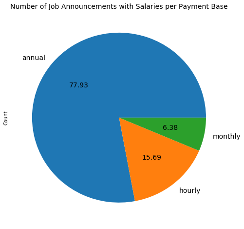

```python
temp.set_index('Base', inplace = True)
temp.Count.plot.pie(autopct='%.2f', figsize = (8,8), fontsize = 14)
plt.title('Number of Job Announcements with Salaries per Payment Base', fontsize = 14)
plt.show()
```

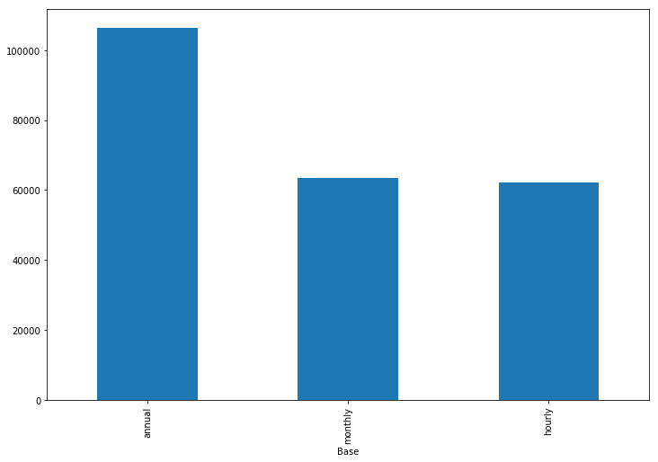

```python
temp['Mean'].sort_values(ascending = False).plot(figsize = (12,8),kind = 'bar')
plt.show()
```

### Now building a dummy variable comparing salaries to the median of USD

- Since the annual salary is significantly different from salaries paid on monthl or hourly basis I decided to drop those.
- Re-measure the median only for the annual salaries

```python
jobs = jobs[jobs.paybase == 'annual']
median_ = jobs.salarytxt.median()
print median_
```

```
97200.0
```

```python
jobs.shape
```

```
(452, 15)
```

## Categorizing Data

- creating a dummy variable: True (1) if > median, False (0) if < median

```python
# If the salary is higher than the city median, then it's ONE
jobs['sal_to_med'] = (jobs.salarytxt > median_)
jobs.head()
```

|  | jobtitle | company | location | salarytxt | paybase | summary | City | State | Population | Density | DPF | Latitude | Longitude | MedianHHInc | Ppower | sal_to_med |
| --- | --- | --- | --- | --- | --- | --- | --- | --- | --- | --- | --- | --- | --- | --- | --- | --- |
| 0 | sr data scientist | Fimo Info Solutions LLC | New York, NY | 110000.0 | annual | sr data scientist, nyc*. the data scientist wi... | New+York%2CNY | New York | 8537673 | 27012 | 230619.62 | 40.6643 | 73.9385 | 59799.0 | 100.0 | True |
| 1 | climate and sustainability analyst | DEPT OF ENVIRONMENT PROTECTION | New York, NY | 65977.0 | annual | knowledge and practical application of quantit... | New+York%2CNY | New York | 8537673 | 27012 | 230619.62 | 40.6643 | 73.9385 | 59799.0 | 100.0 | False |
| 2 | data analyst | POLICE DEPARTMENT | New York, NY | 79249.5 | annual | extensive knowledge of applied statistics, ana... | New+York%2CNY | New York | 8537673 | 27012 | 230619.62 | 40.6643 | 73.9385 | 59799.0 | 100.0 | False |
| 5 | geospatial data scientist | DEPARTMENT OF FINANCE | Manhattan, NY | 75643.0 | annual | the property valuation & mapping unit is seeki... | New+York%2CNY | New York | 8537673 | 27012 | 230619.62 | 40.6643 | 73.9385 | 59799.0 | 100.0 | False |
| 9 | senior data engineer | Enterprise Select | New York, NY 10011 (Chelsea area) | 140000.0 | annual | ensure data pipeline provides clean organized,... | New+York%2CNY | New York | 8537673 | 27012 | 230619.62 | 40.6643 | 73.9385 | 59799.0 | 100.0 | True |